# Tugas Praktikum 1 Pemulusan dan Peramalan

Adinda Maudy Maulidya

2025-08-31

## Input Data

Data yang digunakan adalah data penjualan es krim perbulannya.

```r
library(rio)
data_all <- import("https://raw.githubusercontent.com/gryoirsyad/mpdw/refs/heads/main/ice_cream.csv")
data_ice <- data_all[116:230,]
```

## Eksplorasi Data

```r
View(data_ice) # Melihat data
str(data_ice) # Struktur data
```

```
## 'data.frame':    115 obs. of  2 variables:
##  $ DATE     : IDate, format: "1981-08-01" "1981-09-01" ...
##  $ IPN31152N: num  106.1 91.5 76.9 71 66.6 ...
```

```r
dim(data_ice) # Dimensi data
```

```
## [1] 115   2
```

Mengubah data sebagai data deret waktu

```r
data_ice.ts <- ts(data_ice$IPN31152N)
data_ice.ts
```

```
## Time Series:
## Start = 1
## End = 115
## Frequency = 1
##   [1] 106.1196  91.4711  76.9246  71.0281  66.5992  62.0754  77.0295  88.5032
##   [9]  86.2440  93.3385 106.9338 101.1462  98.2014  86.1862  72.0738  66.0278
##  [17]  61.4690  63.5263  74.3646  86.6512  83.5305  94.3514 110.2263 107.5508
##  [25] 105.2968  95.8909  79.0648  70.3554  65.5867  67.0011  85.6144  96.7755
##  [33] 101.8245 108.3343 128.8405 125.1273 116.6079 106.8885  88.2627  80.3855
##  [41]  73.9740  76.1736  86.6116 101.2354 104.8666 114.3180 130.5975 124.5167
##  [49] 117.4459 104.0654  86.2262  74.6592  70.6329  73.6820  88.9355 100.0295
##  [57] 104.3014 113.2964 127.3228 121.3230 119.0790  96.8704  86.4120  76.9717
##  [65]  70.6204  73.9480  94.5373 103.6022 106.8190 116.8105 132.0080 127.4044
##  [73] 123.6748 106.7224  89.4039  84.6298  79.7024  79.9002  98.0175 115.0920
##  [81] 119.3721 130.0414 150.9298 145.4406 140.7433 117.3826 100.0984  87.7763
##  [89]  83.0951  87.6177 104.3502 115.4340 121.1818 126.1014 140.4695 135.0524
##  [97] 128.2777 110.4963  97.4270  90.7381  86.0141  82.5291 103.7776 117.2887
## [105] 121.9508 126.5316 141.2775 143.6218 129.0701 114.4056  98.3530  87.9189
## [113]  85.7338  85.2665 104.8588
```

Menampilkan ringkasan data

```r
summary(data_ice.ts)
```

```
##    Min. 1st Qu.  Median    Mean 3rd Qu.    Max.
##   61.47   84.95   98.35   99.92  116.71  150.93
```

```r
library(tseries)
adf.test(data_ice.ts)
```

```
##
##  Augmented Dickey-Fuller Test
##
## data:  data_ice.ts
## Dickey-Fuller = -9.655, Lag order = 4, p-value = 0.01
## alternative hypothesis: stationary
```

p-value < 0.05 menyebabkan tolak H0 dan artinya data stasioner.

Selanjutnya membuat *plot time-series* dari Data penjualan es krim perbulan.

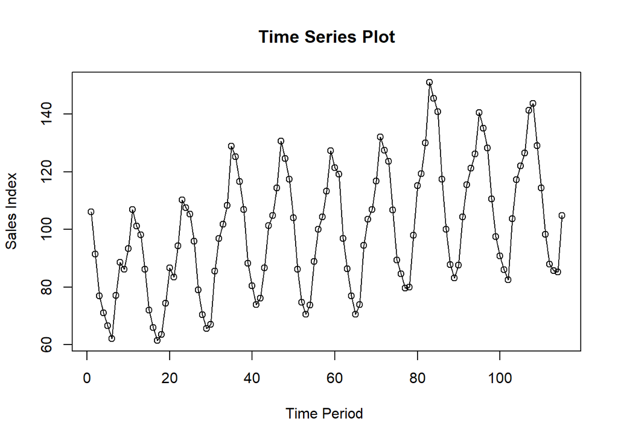

```r
ts.plot(data_ice.ts, xlab="Time Period ", ylab="Sales Index",
        main = "Time Series Plot")
points(data_ice.ts)
```

## Single Moving Average (SMA) dan Single Exponentional Smoothing (SES)

Selanjutnya akan dilakukan ramalan dan pemulusan dengan metode SMA dan SES karena pola data stasioner atau konstan.

#### Pembagian Data

Pembagian data latih (80%) dan data uji (20%).

```r
training_ma <- data_ice[1:92,]
testing_ma <- data_ice[93:115,]
train_ma.ts <- ts(training_ma$IPN31152N)
test_ma.ts <- ts(testing_ma$IPN31152N)
```

#### Eksplorasi Data

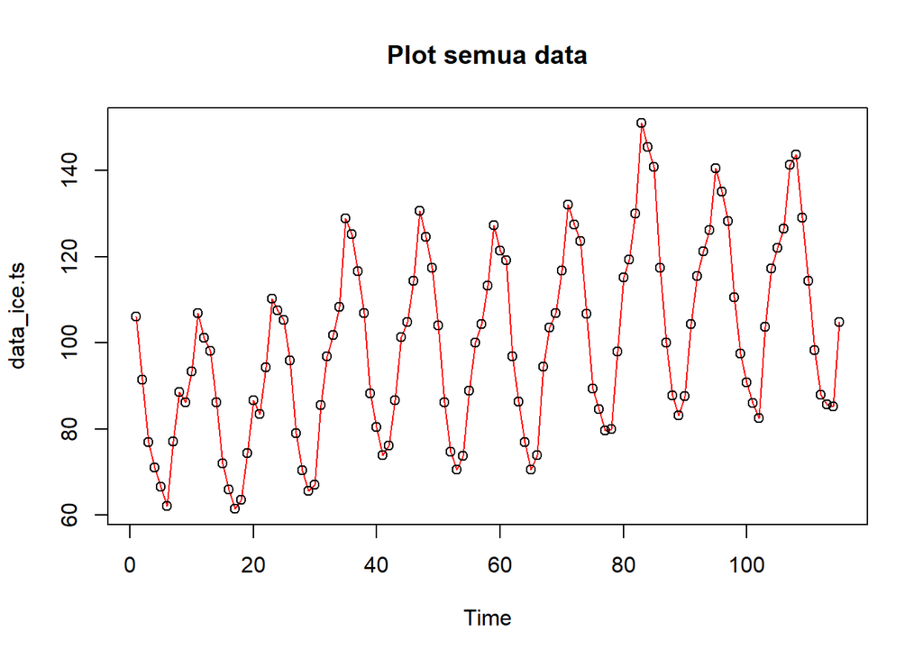

```r
# keseluruhan
plot(data_ice.ts, col="red",main="Plot semua data")
points(data_ice.ts)
```

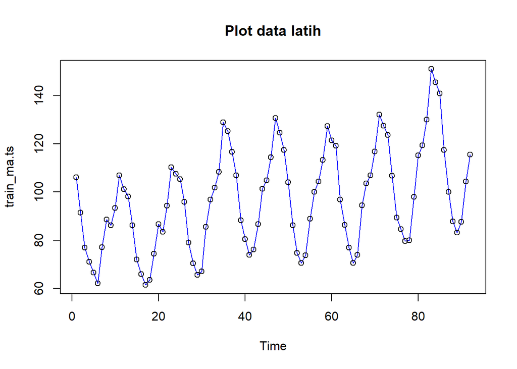

```r
# data latih
plot(train_ma.ts, col="blue",main="Plot data latih")
points(train_ma.ts)
```

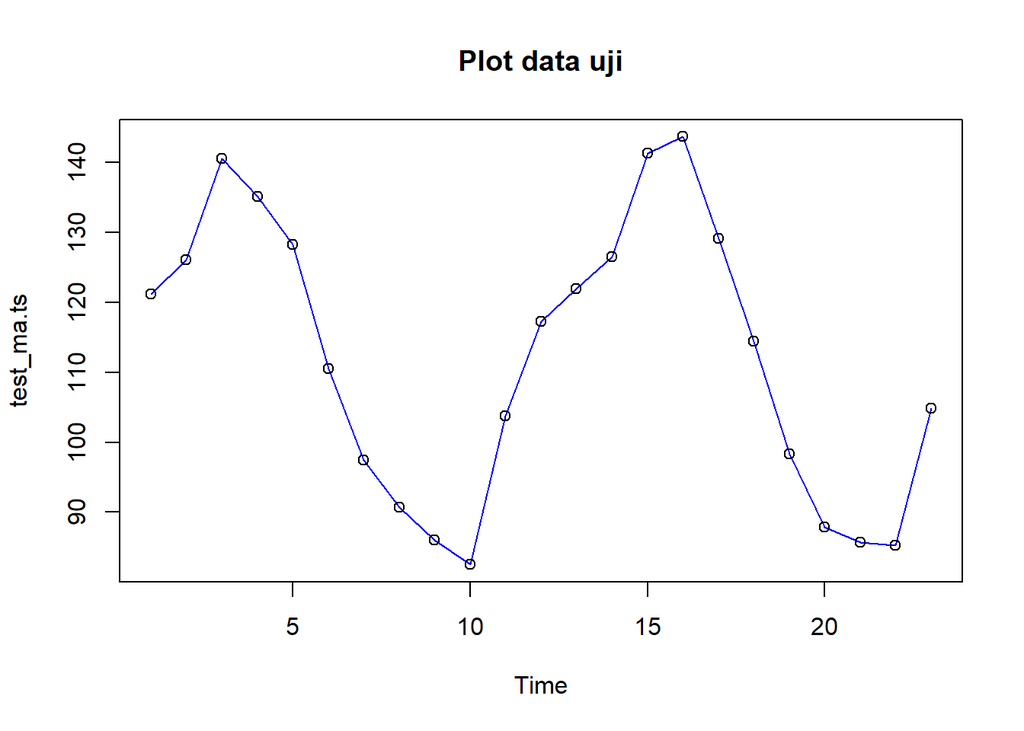

```r
# data uji
plot(test_ma.ts, col="blue",main="Plot data uji")
points(test_ma.ts)
```

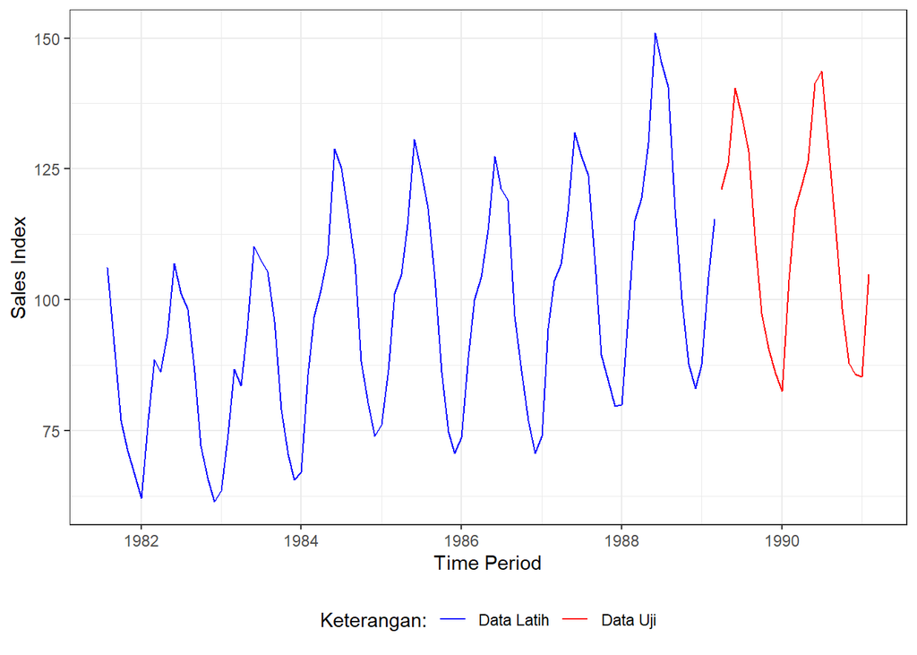

```r
library(ggplot2)
ggplot() +
  # garis untuk data latih
  geom_line(data = training_ma, aes(x = DATE, y = IPN31152N, col = "Data Latih")) +
  # garis untuk data uji
  geom_line(data = testing_ma, aes(x = DATE, y = IPN31152N, col = "Data Uji")) +
  # label sumbu dan legenda
  labs(x = "Time Period", y = "Sales Index", color = "Keterangan") +
  # atur warna manual
  scale_colour_manual(
    name = "Keterangan:",
    breaks = c("Data Latih", "Data Uji"),
    values = c("blue", "red")
  ) +
  # tema
  theme_bw() +
  theme(
    legend.position = "bottom",
    plot.caption = element_text(hjust = 0.5, size = 12)
  )
```

#### SMA

Pemulusan menggunakan metode SMA dengan fungsi *SMA()* dan parameter *m=2*

```r
library(TTR)
data.sma <- SMA(train_ma.ts, n=2)
data.sma
```

```
## Time Series:
## Start = 1
## End = 92
## Frequency = 1
##  [1]        NA  98.79535  84.19785  73.97635  68.81365  64.33730  69.55245
##  [8]  82.76635  87.37360  89.79125 100.13615 104.04000  99.67380  92.19380
## [15]  79.13000  69.05080  63.74840  62.49765  68.94545  80.50790  85.09085
## [22]  88.94095 102.28885 108.88855 106.42380 100.59385  87.47785  74.71010
## [29]  67.97105  66.29390  76.30775  91.19495  99.30000 105.07940 118.58740
## [36] 126.98390 120.86760 111.74820  97.57560  84.32410  77.17975  75.07380
## [43]  81.39260  93.92350 103.05100 109.59230 122.45775 127.55710 120.98130
## [50] 110.75565  95.14580  80.44270  72.64605  72.15745  81.30875  94.48250
## [57] 102.16545 108.79890 120.30960 124.32290 120.20100 107.97470  91.64120
## [64]  81.69185  73.79605  72.28420  84.24265  99.06975 105.21060 111.81475
## [71] 124.40925 129.70620 125.53960 115.19860  98.06315  87.01685  82.16610
## [78]  79.80130  88.95885 106.55475 117.23205 124.70675 140.48560 148.18520
## [85] 143.09195 129.06295 108.74050  93.93735  85.43570  85.35640  95.98395
## [92] 109.89210
```

Dilakukan peramalan 1 periode ke depan

```r
data.ramal <- c(NA, data.sma)
data.ramal
```

```
##  [1]        NA        NA  98.79535  84.19785  73.97635  68.81365  64.33730
##  [8]  69.55245  82.76635  87.37360  89.79125 100.13615 104.04000  99.67380
## [15]  92.19380  79.13000  69.05080  63.74840  62.49765  68.94545  80.50790
## [22]  85.09085  88.94095 102.28885 108.88855 106.42380 100.59385  87.47785
## [29]  74.71010  67.97105  66.29390  76.30775  91.19495  99.30000 105.07940
## [36] 118.58740 126.98390 120.86760 111.74820  97.57560  84.32410  77.17975
## [43]  75.07380  81.39260  93.92350 103.05100 109.59230 122.45775 127.55710
## [50] 120.98130 110.75565  95.14580  80.44270  72.64605  72.15745  81.30875
## [57]  94.48250 102.16545 108.79890 120.30960 124.32290 120.20100 107.97470
## [64]  91.64120  81.69185  73.79605  72.28420  84.24265  99.06975 105.21060
## [71] 111.81475 124.40925 129.70620 125.53960 115.19860  98.06315  87.01685
## [78]  82.16610  79.80130  88.95885 106.55475 117.23205 124.70675 140.48560
## [85] 148.18520 143.09195 129.06295 108.74050  93.93735  85.43570  85.35640
## [92]  95.98395 109.89210
```

```r
data.gab<-cbind(aktual=c(train_ma.ts,rep(NA,41)),pemulusan=c(data.sma,rep(NA,41)),ramalan=c(data.ramal,rep(data.ramal[length(data.ramal)],40)))
data.gab
```

```
##          aktual pemulusan   ramalan
##   [1,] 106.1196        NA        NA
##   [2,]  91.4711  98.79535        NA
##   [3,]  76.9246  84.19785  98.79535
##   [4,]  71.0281  73.97635  84.19785
##   [5,]  66.5992  68.81365  73.97635
##   [6,]  62.0754  64.33730  68.81365
##   [7,]  77.0295  69.55245  64.33730
##   [8,]  88.5032  82.76635  69.55245
##   [9,]  86.2440  87.37360  82.76635
##  [10,]  93.3385  89.79125  87.37360
##  [11,] 106.9338 100.13615  89.79125
##  [12,] 101.1462 104.04000 100.13615
##  [13,]  98.2014  99.67380 104.04000
##  [14,]  86.1862  92.19380  99.67380
```

[output cut: 119 more lines]

Plot time series dari hasil peramalan sebagai berikut

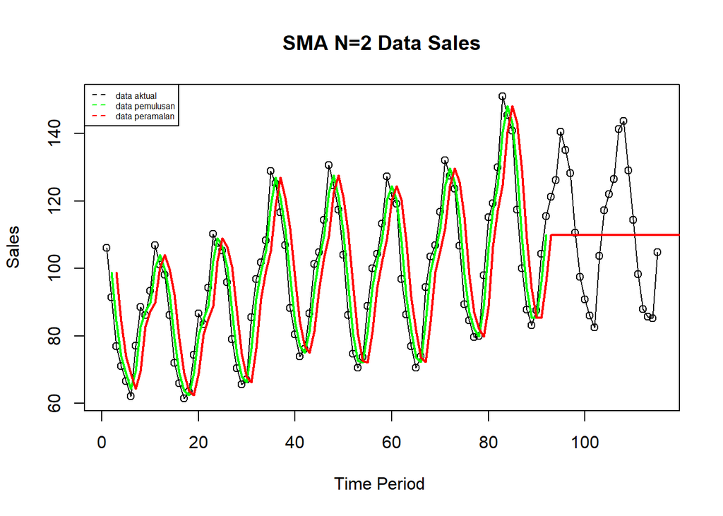

```r
ts.plot(data_ice.ts, xlab="Time Period ", ylab="Sales", main= "SMA N=2 Data Sales")
points(data_ice.ts)
lines(data.gab[,2],col="green",lwd=2)
lines(data.gab[,3],col="red",lwd=2)
legend("topleft",c("data aktual","data pemulusan","data peramalan"), lty=8, col=c("black","green","red"), cex=0.5)
```

Dilakukan perhitungan akurasi pada data latih

```r
error_train.sma = train_ma.ts-data.ramal[1:length(train_ma.ts)]
SSE_train.sma = sum(error_train.sma[5:length(train_ma.ts)]^2)
MSE_train.sma = mean(error_train.sma[5:length(train_ma.ts)]^2)
MAPE_train.sma = mean(abs((error_train.sma[5:length(train_ma.ts)]/train_ma.ts[5:length(train_ma.ts)])*100))

akurasi_train.sma <- matrix(c(SSE_train.sma, MSE_train.sma, MAPE_train.sma))
row.names(akurasi_train.sma)<- c("SSE", "MSE", "MAPE")
colnames(akurasi_train.sma) <- c("Akurasi m = 2")
akurasi_train.sma
```

```
##      Akurasi m = 2
## SSE     19644.6256
## MSE       223.2344
## MAPE       13.5597
```

Didapatkan nilai MAPE data latih pada metode pemulusan SMA kurang dari 20%, artinya nilai ini cukup baik atau dapat diterima. Dilakukan perhituangan akurasi pada data uji

```r
error_test.sma = test_ma.ts-data.gab[93:115,3]
SSE_test.sma = sum(error_test.sma^2)
MSE_test.sma = mean(error_test.sma^2)
MAPE_test.sma = mean(abs((error_test.sma/test_ma.ts*100)))

akurasi_test.sma <- matrix(c(SSE_test.sma, MSE_test.sma, MAPE_test.sma))
row.names(akurasi_test.sma)<- c("SSE", "MSE", "MAPE")
colnames(akurasi_test.sma) <- c("Akurasi m = 2")
akurasi_test.sma
```

```
##      Akurasi m = 2
## SSE     8994.39471
## MSE      391.06064
## MAPE      16.11273
```

Perhituangan akurasi menggunakan data uji menghasilkan nilai MAPE kurang dari 20%, sehingga nilai akurasi ini dapat dikategorikan cukup baik.

#### Pembagian Data

Pembagian data latih 80% dan data uji 20%

```r
training <- data_ice[1:92,]
testing <- data_ice[93:115,]
train.ts <- ts(training$IPN31152N)
test.ts <- ts(testing$IPN31152N)
```

#### Eksplorasi Data

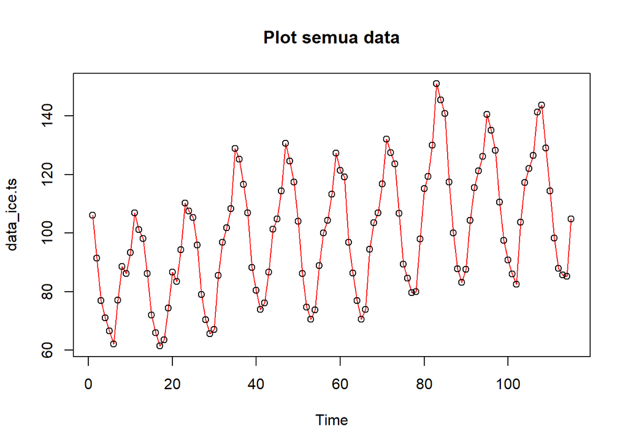

```r
# keseluruhan
plot(data_ice.ts, col="red",main="Plot semua data")
points(data_ice.ts)
```

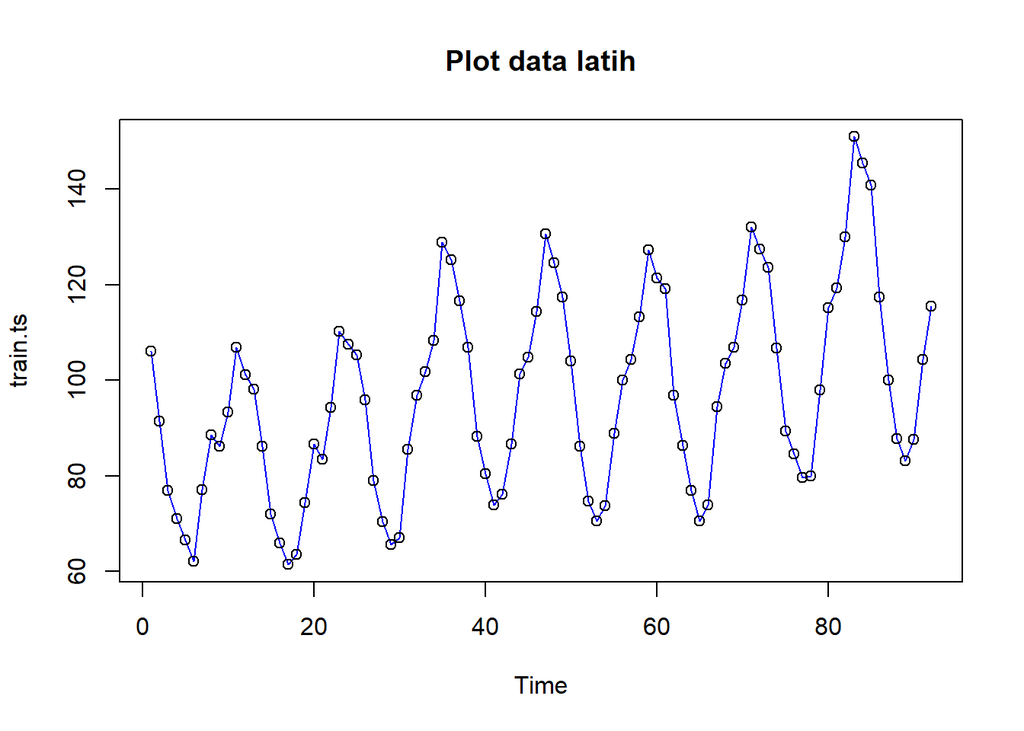

```r
# data latih
plot(train.ts, col="blue",main="Plot data latih")
points(train.ts)
```

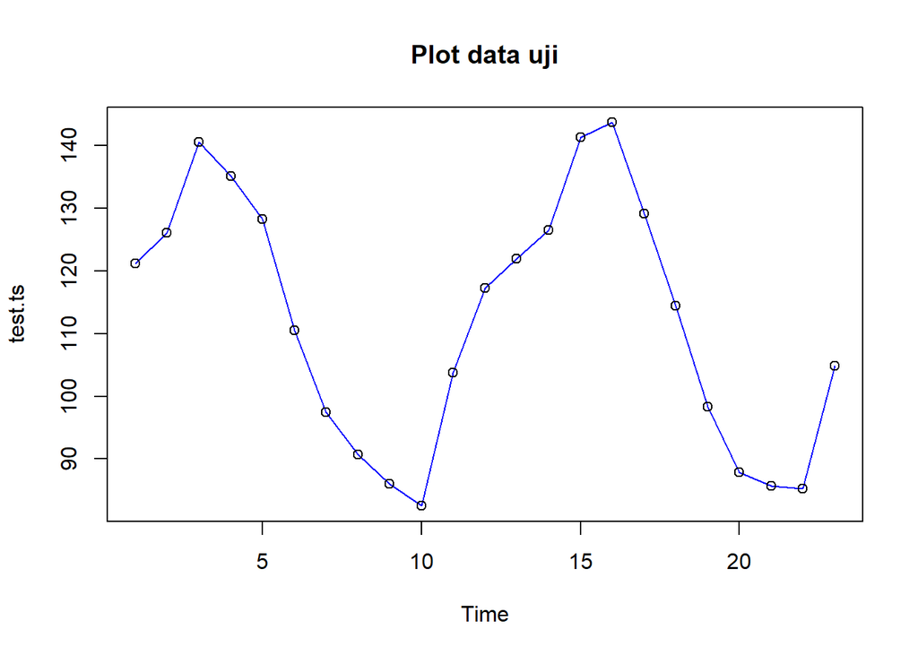

```r
# data uji
plot(test.ts, col="blue",main="Plot data uji")
points(test.ts)
```

Eksplorasi dengan package *ggplot2*

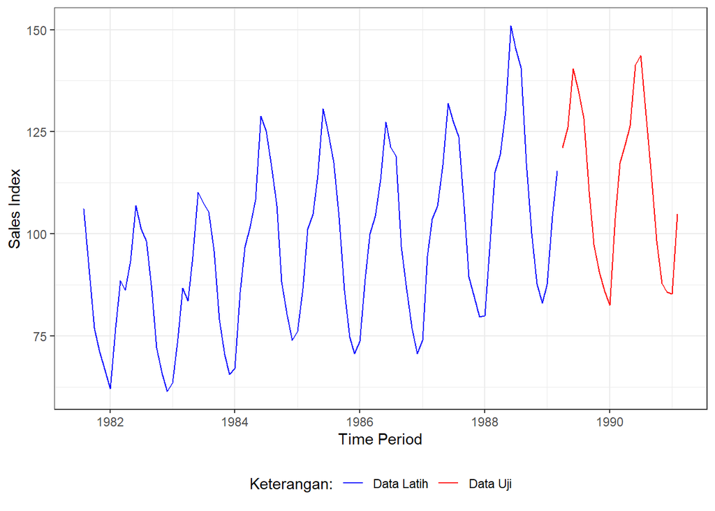

```r
ggplot() +
  # garis untuk data latih
  geom_line(data = training_ma, aes(x = DATE, y = IPN31152N, col = "Data Latih")) +
  # garis untuk data uji
  geom_line(data = testing_ma, aes(x = DATE, y = IPN31152N, col = "Data Uji")) +
  # label sumbu dan legenda
  labs(x = "Time Period", y = "Sales Index", color = "Keterangan") +
  # atur warna manual
  scale_colour_manual(
    name = "Keterangan:",
    breaks = c("Data Latih", "Data Uji"),
    values = c("blue", "red")
  ) +
  # tema
  theme_bw() +
  theme(
    legend.position = "bottom",
    plot.caption = element_text(hjust = 0.5, size = 12)
  )
```

#### SES

Cara pertama adalah menggunakan fungsi *ses()* dari packages *forecast* dengan banyak periode data yang akan diramalkan adalah 23 periode dan nilai *alpha* 0,2 dan 0,7.

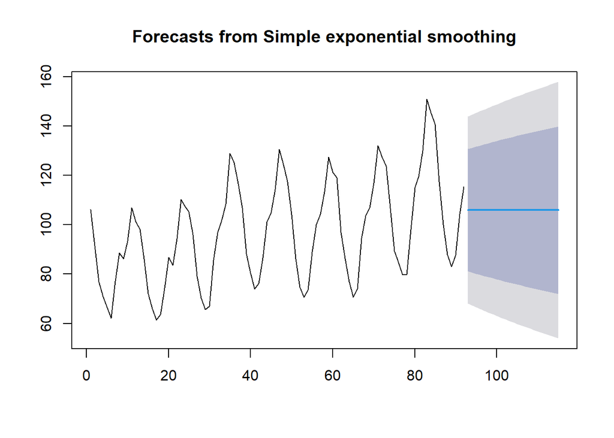

```r
library(forecast)
ses.1 <- ses(train.ts, h = 23, alpha = 0.2)
plot(ses.1)
```

```r
ses.1
```

```
##     Point Forecast    Lo 80    Hi 80    Lo 95    Hi 95
##  93       105.9062 81.13506 130.6773 68.02202 143.7904
##  94       105.9062 80.64450 131.1679 67.27176 144.5406
##  95       105.9062 80.16328 131.6491 66.53580 145.2766
##  96       105.9062 79.69089 132.1215 65.81335 145.9991
##  97       105.9062 79.22687 132.5855 65.10368 146.7087
##  98       105.9062 78.77078 133.0416 64.40616 147.4063
##  99       105.9062 78.32223 133.4902 63.72016 148.0922
## 100       105.9062 77.88086 133.9315 63.04514 148.7673
## 101       105.9062 77.44633 134.3661 62.38059 149.4318
## 102       105.9062 77.01834 134.7941 61.72603 150.0864
## 103       105.9062 76.59660 135.2158 61.08103 150.7314
## 104       105.9062 76.18084 135.6316 60.44518 151.3672
## 105       105.9062 75.77081 136.0416 59.81810 151.9943
## 106       105.9062 75.36629 136.4461 59.19944 152.6130
## 107       105.9062 74.96706 136.8453 58.58887 153.2235
## 108       105.9062 74.57292 137.2395 57.98608 153.8263
## 109       105.9062 74.18367 137.6287 57.39077 154.4216
## 110       105.9062 73.79914 138.0133 56.80268 155.0097
## 111       105.9062 73.41916 138.3932 56.22156 155.5908
## 112       105.9062 73.04357 138.7688 55.64715 156.1653
## 113       105.9062 72.67223 139.1402 55.07923 156.7332
## 114       105.9062 72.30500 139.5074 54.51759 157.2948
## 115       105.9062 71.94173 139.8707 53.96202 157.8504
```

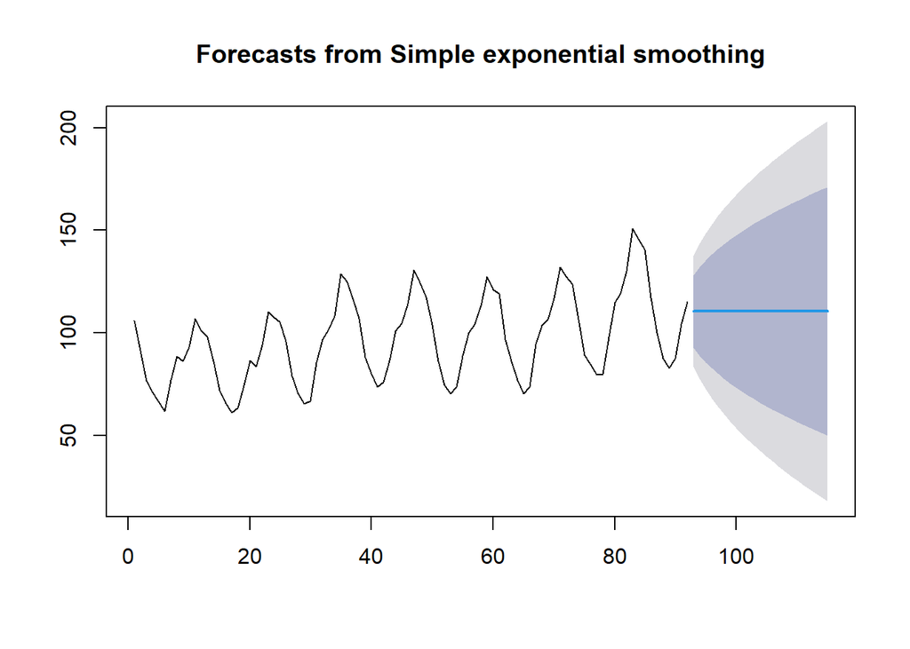

```r
ses.2<- ses(train.ts, h = 23, alpha = 0.7)
plot(ses.2)
```

```r
ses.2
```

```
##     Point Forecast    Lo 80    Hi 80    Lo 95    Hi 95
##  93       110.5667 92.95774 128.1756 83.63615 137.4972
##  94       110.5667 89.07224 132.0611 77.69378 143.4395
##  95       110.5667 85.78872 135.3446 72.67207 148.4613
##  96       110.5667 82.89208 138.2412 68.24203 152.8913
##  97       110.5667 80.27113 140.8622 64.23365 156.8997
##  98       110.5667 77.85955 143.2738 60.54545 160.5879
##  99       110.5667 75.61396 145.5194 57.11111 164.0222
## 100       110.5667 73.50418 147.6291 53.88448 167.2488
## 101       110.5667 71.50819 149.6251 50.83189 170.3014
## 102       110.5667 69.60936 151.5240 47.92788 173.2054
## 103       110.5667 67.79475 153.3386 45.15267 175.9807
## 104       110.5667 66.05405 155.0793 42.49049 178.6428
## 105       110.5667 64.37890 156.7544 39.92858 181.2047
## 106       110.5667 62.76242 158.3709 37.45639 183.6769
## 107       110.5667 61.19884 159.9345 35.06510 186.0682
## 108       110.5667 59.68329 161.4500 32.74726 188.3861
## 109       110.5667 58.21159 162.9217 30.49648 190.6368
## 110       110.5667 56.78014 164.3532 28.30727 192.8261
## 111       110.5667 55.38581 165.7475 26.17483 194.9585
## 112       110.5667 54.02586 167.1075 24.09496 197.0384
## 113       110.5667 52.69785 168.4355 22.06396 199.0694
## 114       110.5667 51.39965 169.7337 20.07853 201.0548
## 115       110.5667 50.12933 171.0040 18.13573 202.9976
```

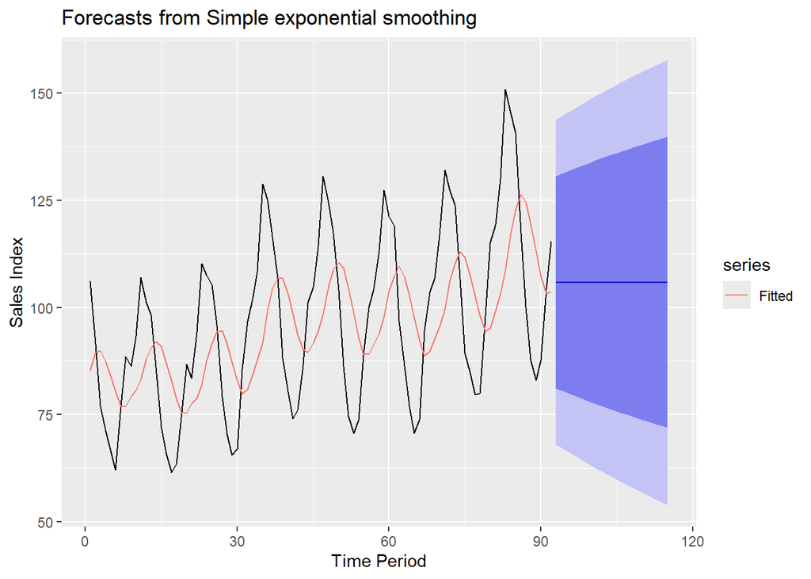

```r
autoplot(ses.1) +
  autolayer(fitted(ses.1), series="Fitted") +
  ylab("Sales Index") + xlab("Time Period")
```

Cara kedua adalah menggunakan fungsi *HoltWinters()* dengan inisialisasi parameter dan panjang periode peramalan yang sama dengan fungsi ses()

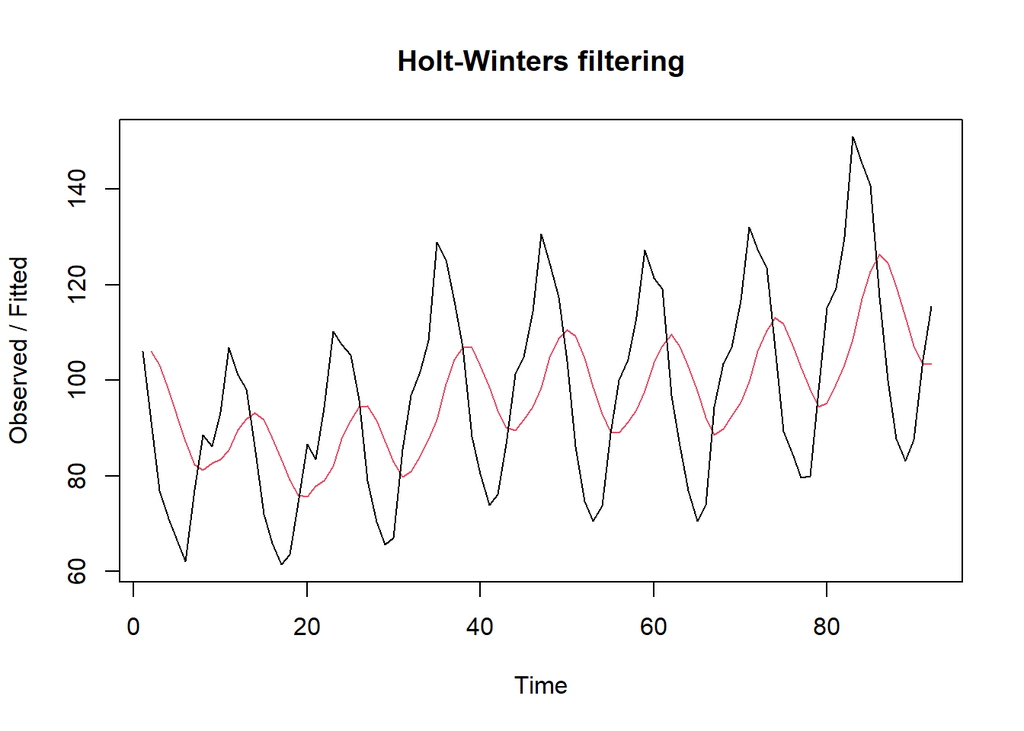

```r
ses1<- HoltWinters(train.ts, gamma = FALSE, beta = FALSE, alpha = 0.2)
plot(ses1)
```

```r
# ramalan
ramalan1 <- forecast(ses1, h=23)
ramalan1
```

```
##     Point Forecast    Lo 80    Hi 80    Lo 95    Hi 95
##  93       105.9062 80.69606 131.1163 67.35061 144.4618
##  94       105.9062 80.19680 131.6156 66.58706 145.2253
##  95       105.9062 79.70705 132.1054 65.83806 145.9743
##  96       105.9062 79.22629 132.5861 65.10280 146.7096
##  97       105.9062 78.75405 133.0584 64.38056 147.4318
##  98       105.9062 78.28987 133.5225 63.67067 148.1417
##  99       105.9062 77.83337 133.9790 62.97251 148.8399
## 100       105.9062 77.38418 134.4282 62.28553 149.5269
## 101       105.9062 76.94195 134.8705 61.60920 150.2032
## 102       105.9062 76.50637 135.3060 60.94304 150.8694
## 103       105.9062 76.07716 135.7353 60.28661 151.5258
## 104       105.9062 75.65403 136.1584 59.63949 152.1729
## 105       105.9062 75.23674 136.5757 59.00130 152.8111
## 106       105.9062 74.82505 136.9874 58.37168 153.4407
## 107       105.9062 74.41874 137.3937 57.75029 154.0621
## 108       105.9062 74.01761 137.7948 57.13681 154.6756
## 109       105.9062 73.62146 138.1909 56.53096 155.2815
## 110       105.9062 73.23012 138.5823 55.93245 155.8800
## 111       105.9062 72.84341 138.9690 55.34102 156.4714
## 112       105.9062 72.46117 139.3512 54.75643 157.0560
## 113       105.9062 72.08324 139.7292 54.17845 157.6340
## 114       105.9062 71.70950 140.1029 53.60686 158.2056
## 115       105.9062 71.33979 140.4726 53.04144 158.7710
```

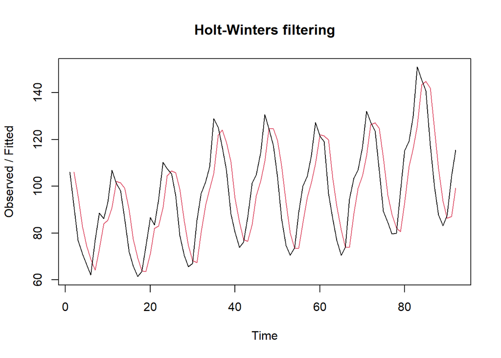

```r
ses2<- HoltWinters(train.ts, gamma = FALSE, beta = FALSE, alpha = 0.7)
plot(ses2)
```

```r
# ramalan
ramalan2<- forecast(ses2, h=23)
ramalan2
```

```
##     Point Forecast    Lo 80    Hi 80    Lo 95    Hi 95
##  93       110.5667 92.93819 128.1951 83.60624 137.5271
##  94       110.5667 89.04837 132.0850 77.65727 143.4761
##  95       110.5667 85.76120 135.3721 72.62998 148.5033
##  96       110.5667 82.86134 138.2720 68.19503 152.9383
##  97       110.5667 80.23749 140.8958 64.18220 156.9511
##  98       110.5667 77.82323 143.3101 60.48990 160.6434
##  99       110.5667 75.57514 145.5582 57.05175 164.0816
## 100       110.5667 73.46302 147.6703 53.82153 167.3118
## 101       110.5667 71.46482 149.6685 50.76555 170.3678
## 102       110.5667 69.56388 151.5694 47.85832 173.2750
## 103       110.5667 67.74725 153.3861 45.08002 176.0533
## 104       110.5667 66.00461 155.1287 42.41489 178.7184
## 105       110.5667 64.32761 156.8057 39.85013 181.2832
## 106       110.5667 62.70933 158.4240 37.37519 183.7581
## 107       110.5667 61.14402 159.9893 34.98125 186.1521
## 108       110.5667 59.62678 161.5065 32.66083 188.4725
## 109       110.5667 58.15344 162.9799 30.40756 190.7258
## 110       110.5667 56.72040 164.4129 28.21592 192.9174
## 111       110.5667 55.32453 165.8088 26.08111 195.0522
## 112       110.5667 53.96306 167.1703 23.99893 197.1344
## 113       110.5667 52.63359 168.4997 21.96567 199.1677
## 114       110.5667 51.33394 169.7994 19.97803 201.1553
## 115       110.5667 50.06221 171.0711 18.03308 203.1002
```

Mengoptimalkan nilai parameter alpha dari kedua fungsi dengan menyesuaikan dari error-nya paling minimum (*alpha = NULL*)

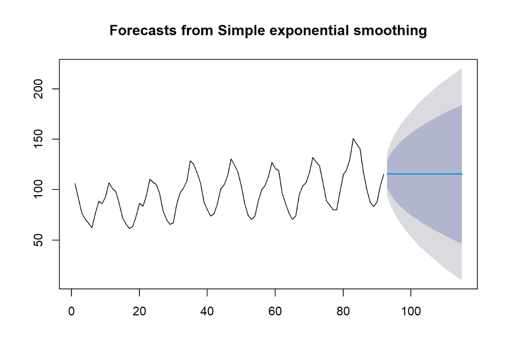

```r
ses.opt <- ses(train.ts, h = 23, alpha = NULL)
plot(ses.opt)
```

```r
ses.opt
```

```
##     Point Forecast     Lo 80    Hi 80     Lo 95    Hi 95
##  93       115.4329 101.04728 129.8185 93.432003 137.4338
##  94       115.4329  95.08959 135.7762 84.320493 146.5453
##  95       115.4329  90.51795 140.3478 77.328776 153.5370
##  96       115.4329  86.66383 144.2019 71.434415 159.4314
##  97       115.4329  83.26827 147.5975 66.241346 164.6244
##  98       115.4329  80.19843 150.6674 61.546433 169.3193
##  99       115.4329  77.37541 153.4904 57.229002 173.6368
## 100       115.4329  74.74781 156.1180 53.210428 177.6554
## 101       115.4329  72.27991 158.5859 49.436094 181.4297
## 102       115.4329  69.94570 160.9201 45.866236 184.9995
## 103       115.4329  67.72557 163.1402 42.470834 188.3949
## 104       115.4329  65.60425 165.2615 39.226566 191.6392
## 105       115.4329  63.56963 167.2961 36.114884 194.7509
## 106       115.4329  61.61188 169.2539 33.120750 197.7450
## 107       115.4329  59.72287 171.1429 30.231772 200.6340
## 108       115.4329  57.89586 172.9699 27.437590 203.4282
## 109       115.4329  56.12510 174.7407 24.729444 206.1363
## 110       115.4329  54.40569 176.4601 22.099845 208.7659
## 111       115.4329  52.73342 178.1324 19.542329 211.3235
## 112       115.4329  51.10461 179.7612 17.051277 213.8145
## 113       115.4329  49.51603 181.3497 14.621759 216.2440
## 114       115.4329  47.96485 182.9009 12.249430 218.6164
## 115       115.4329  46.44854 184.4172  9.930432 220.9354
```

```r
#Lamda Optimum Holt Winter
sesopt<- HoltWinters(train.ts, gamma = FALSE, beta = FALSE,alpha = NULL)
sesopt
```

```
## Holt-Winters exponential smoothing without trend and without seasonal component.
##
## Call:
## HoltWinters(x = train.ts, alpha = NULL, beta = FALSE, gamma = FALSE)
##
## Smoothing parameters:
##  alpha: 0.9999339
##  beta : FALSE
##  gamma: FALSE
##
## Coefficients:
##       [,1]
## a 115.4333
```

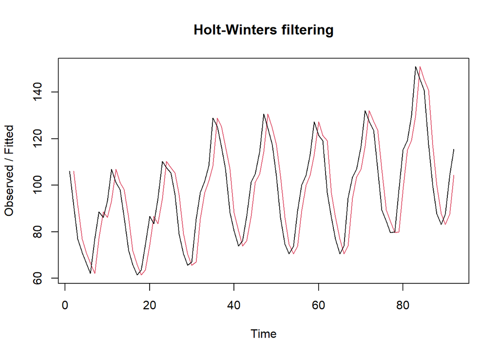

```r
plot(sesopt)
```

```r
# ramalan
ramalanopt <- forecast(sesopt, h=23)
ramalanopt
```

```
##     Point Forecast     Lo 80    Hi 80    Lo 95    Hi 95
##  93       115.4333 101.04854 129.8180 93.43372 137.4328
##  94       115.4333  95.09086 135.7757 84.32224 146.5443
##  95       115.4333  90.51928 140.3473 77.33062 153.5359
##  96       115.4333  86.66524 144.2013 71.43636 159.4302
##  97       115.4333  83.26974 147.5968 66.24339 164.6231
##  98       115.4333  80.19996 150.6666 61.54858 169.3180
##  99       115.4333  77.37701 153.4895 57.23124 173.6353
## 100       115.4333  74.74946 156.1171 53.21276 177.6538
## 101       115.4333  72.28162 158.5849 49.43851 181.4280
## 102       115.4333  69.94747 160.9191 45.86874 184.9978
## 103       115.4333  67.72739 163.1391 42.47342 188.3931
## 104       115.4333  65.60612 165.2604 39.22923 191.6373
## 105       115.4333  63.57155 167.2950 36.11762 194.7489
## 106       115.4333  61.61384 169.2527 33.12356 197.7430
## 107       115.4333  59.72489 171.1416 30.23466 200.6319
## 108       115.4333  57.89792 172.9686 27.44054 203.4260
## 109       115.4333  56.12720 174.7393 24.73247 206.1341
## 110       115.4333  54.40784 176.4587 22.10293 208.7636
## 111       115.4333  52.73561 178.1309 19.54548 211.3211
## 112       115.4333  51.10684 179.7597 17.05449 213.8120
## 113       115.4333  49.51831 181.3482 14.62504 216.2415
## 114       115.4333  47.96717 182.8994 12.25277 218.6138
## 115       115.4333  46.45089 184.4156  9.93383 220.9327
```

#### Akurasi Data

```r
accuracy(ramalanopt,testing$IPN31152N)
```

```
##                      ME     RMSE       MAE        MPE     MAPE     MASE
## Training set  0.1023548 11.16309  9.579685 -0.5838678 10.03334 1.000037
## Test set     -3.3314368 19.93179 17.336425 -6.3210668 16.73412 1.809774
##                   ACF1
## Training set 0.5615518
## Test set            NA
```